# Week3_R_Solutions

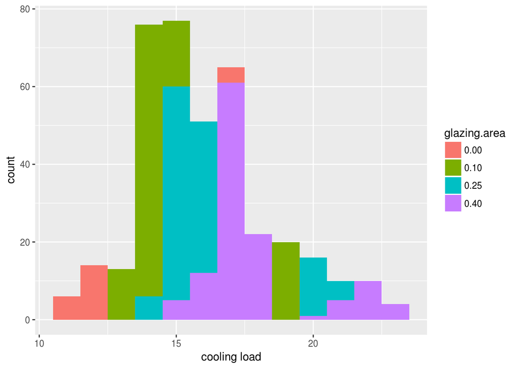

```r
ggplot(eedata3.50, aes(x = cooling.load, fill = glazing.area)) + geom_histogram(binwidth = 1) + labs(x = "cooling load")
```

```r
testlm <- lm(cooling.load ~ glazing.area.actual, data = eedata3.50numeric)
summary(testlm)
```

```
##
## Call:
## lm(formula = cooling.load ~ glazing.area.actual, data = eedata3.50numeric)
##
## Residuals:
##     Min      1Q  Median      3Q     Max
## -2.8375 -0.9960 -0.5046 -0.0055  4.7867
##
## Coefficients:
##                      Estimate Std. Error t value Pr(>|t|)
## (Intercept)         13.432060   0.186494   72.02   <2e-16 ***
## glazing.area.actual  0.036772   0.002238   16.43   <2e-16 ***
## ---
## Signif. codes:  0 '***' 0.001 '**' 0.01 '*' 0.05 '.' 0.1 ' ' 1
##
## Residual standard error: 1.856 on 382 degrees of freedom
## Multiple R-squared:  0.414,  Adjusted R-squared:  0.4125
## F-statistic: 269.9 on 1 and 382 DF,  p-value: < 2.2e-16
```

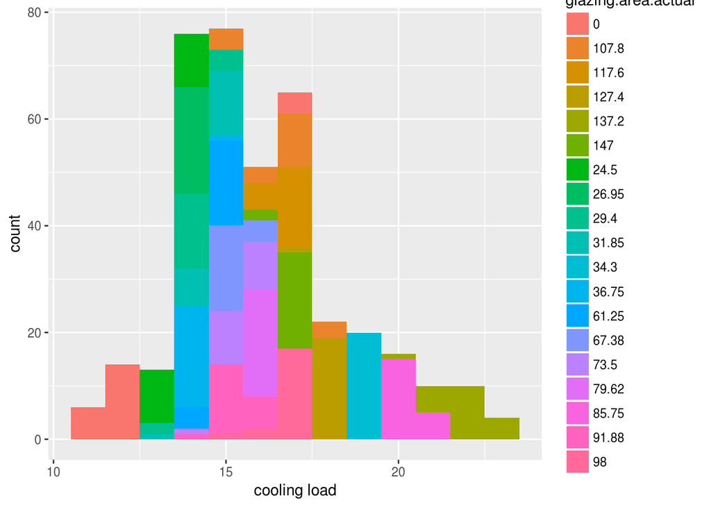

```r
ggplot(eedata3.50, aes(x = cooling.load, fill = glazing.area.actual)) + geom_histogram(binwidth = 1) + labs(x = "cooling load")
```

Glazing area appears to have the biggest impact on the cooling response variable in this subset of data, but not by much.

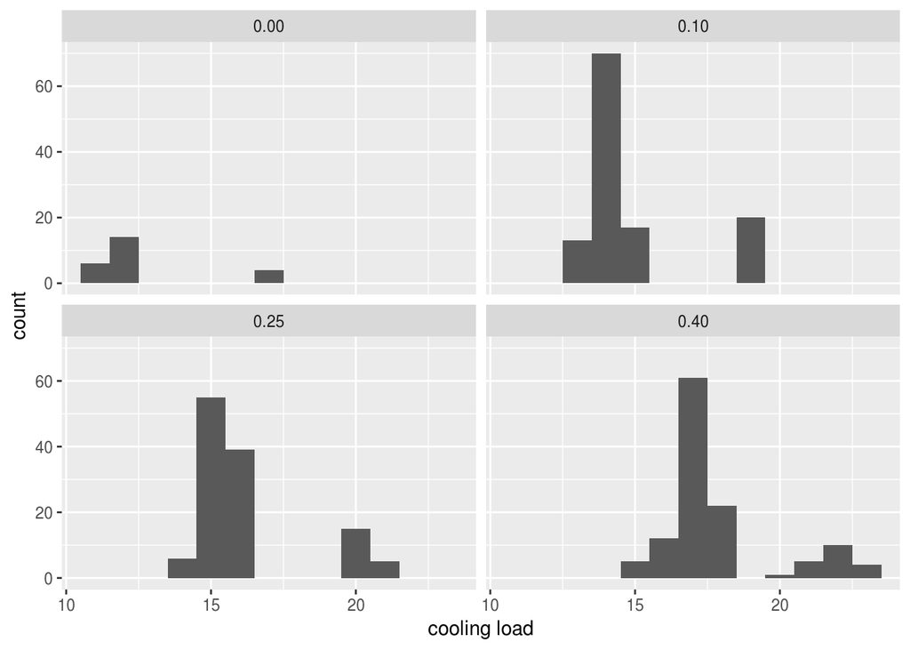

```r
ggplot(eedata3.50, aes(x = cooling.load)) + geom_histogram(binwidth = 1) + labs(x = "cooling load") + facet_wrap(~glazing.area)
```

When a facet wrap is applied, it can be seen that wall area may play a factor in the cooling load as well. It appears that higher glazing ratios and larger wall areas would correlate to larger cooling loads; however, it’s not so clear at the moment.

```r
#Test the two parameters with each other
testlm <- lm(cooling.load ~ glazing.area * wall.area, data = eedatanumeric)
summary(testlm)
```

```
##
## Call:
## lm(formula = cooling.load ~ glazing.area * wall.area, data = eedatanumeric)
##
## Residuals:
##     Min      1Q  Median      3Q     Max
## -15.768  -6.904  -1.271   6.981  18.861
##
## Coefficients:
##                        Estimate Std. Error t value Pr(>|t|)
## (Intercept)            -7.05775    4.51852  -1.562    0.119
## glazing.area            8.45215   16.76330   0.504    0.614
## wall.area               0.08845    0.01406   6.293 5.24e-10 ***
## glazing.area:wall.area  0.01999    0.05215   0.383    0.702
## ---
## Signif. codes:  0 '***' 0.001 '**' 0.01 '*' 0.05 '.' 0.1 ' ' 1
##
## Residual standard error: 8.388 on 764 degrees of freedom
## Multiple R-squared:  0.2256, Adjusted R-squared:  0.2226
## F-statistic: 74.21 on 3 and 764 DF,  p-value: < 2.2e-16
```

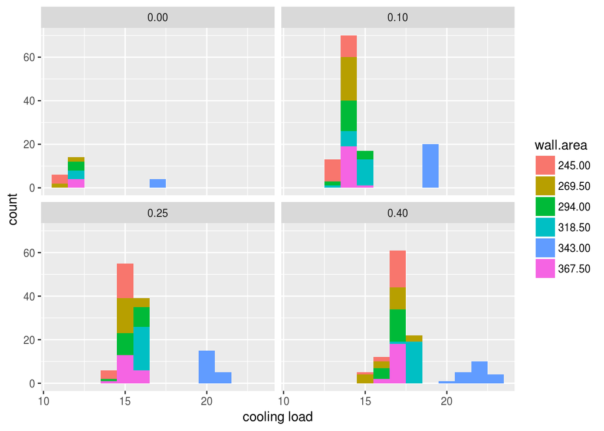

```r
ggplot(eedata3.50, aes(x = cooling.load, fill = wall.area)) + geom_histogram(binwidth = 1) + labs(x = "cooling load") + facet_wrap(~glazing.area)
```

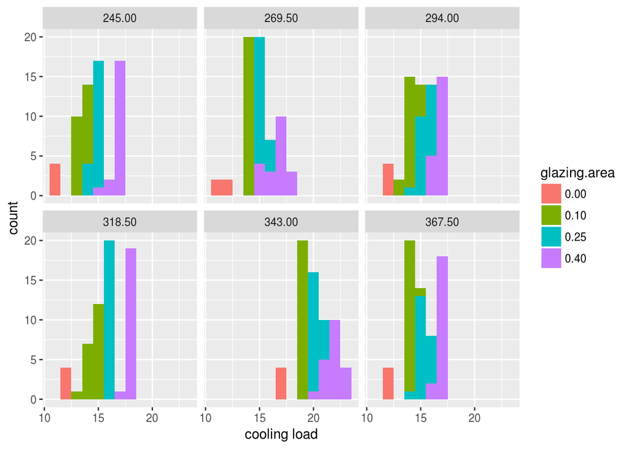

```r
#reverse wrapping
ggplot(eedata3.50, aes(x = cooling.load, fill = glazing.area)) + geom_histogram(binwidth = 1) + labs(x = "cooling load") + facet_wrap(~wall.area)
```

Now we can run the heating analysis.

```r
testlm <- lm(heating.load ~ relative.compactness, data = eedata3.50numeric)
summary(testlm)
```

```
##
## Call:
## lm(formula = heating.load ~ relative.compactness, data = eedata3.50numeric)
##
## Residuals:
##     Min      1Q  Median      3Q     Max
## -6.7531 -1.5668  0.0219  1.5597  5.0494
##
## Coefficients:
##                      Estimate Std. Error t value Pr(>|t|)
## (Intercept)            34.231      1.981   17.28   <2e-16 ***
## relative.compactness  -30.876      2.922  -10.57   <2e-16 ***
## ---
## Signif. codes:  0 '***' 0.001 '**' 0.01 '*' 0.05 '.' 0.1 ' ' 1
##
## Residual standard error: 2.353 on 382 degrees of freedom
## Multiple R-squared:  0.2261, Adjusted R-squared:  0.2241
## F-statistic: 111.6 on 1 and 382 DF,  p-value: < 2.2e-16
```

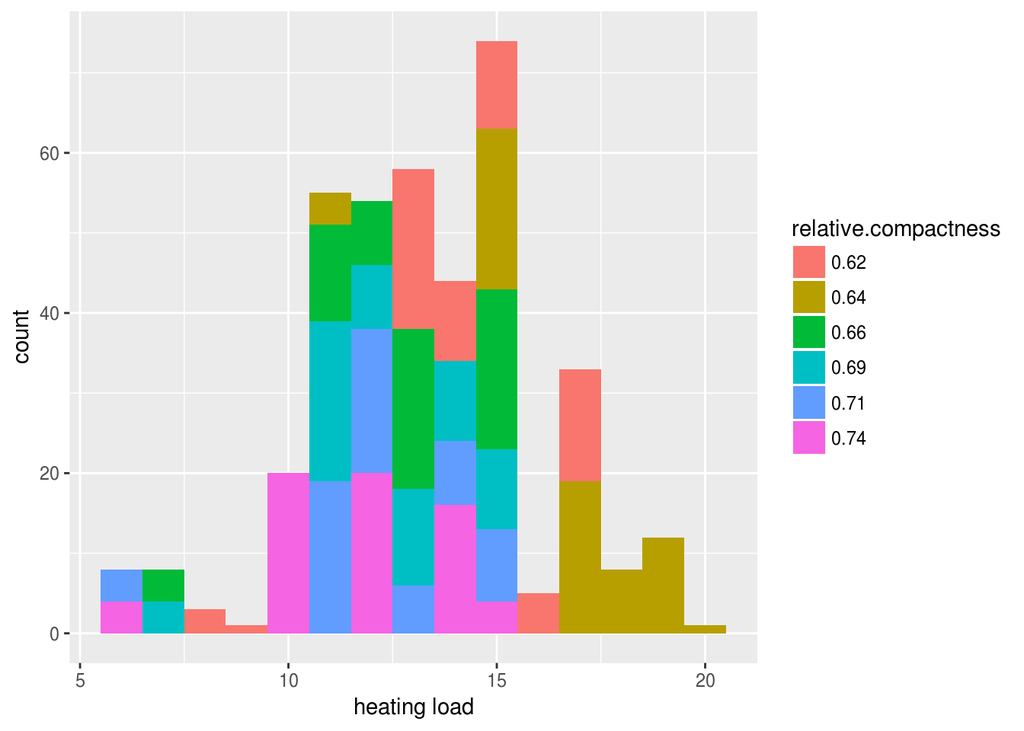

```r
ggplot(eedata3.50, aes(x = heating.load, fill = relative.compactness)) + geom_histogram(binwidth = 1) + labs(x = "heating load")
```

```r
testlm <- lm(heating.load ~ surface.area, data = eedata3.50numeric)
summary(testlm)
```

```
##
## Call:
## lm(formula = heating.load ~ surface.area, data = eedata3.50numeric)
##
## Residuals:
##     Min      1Q  Median      3Q     Max
## -6.7554 -1.5060  0.0566  1.5781  5.0614
##
## Coefficients:
##               Estimate Std. Error t value Pr(>|t|)
## (Intercept)  -9.437223   2.144938   -4.40 1.41e-05 ***
## surface.area  0.030479   0.002866   10.63  < 2e-16 ***
## ---
## Signif. codes:  0 '***' 0.001 '**' 0.01 '*' 0.05 '.' 0.1 ' ' 1
##
## Residual standard error: 2.35 on 382 degrees of freedom
## Multiple R-squared:  0.2284, Adjusted R-squared:  0.2264
## F-statistic: 113.1 on 1 and 382 DF,  p-value: < 2.2e-16
```

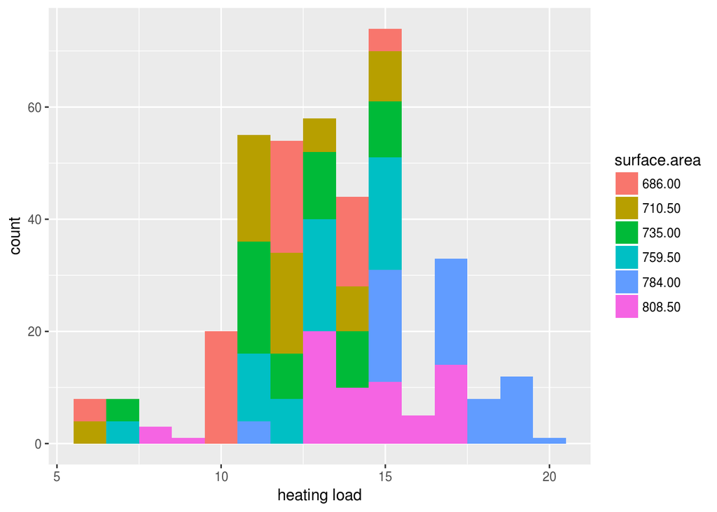

```r
ggplot(eedata3.50, aes(x = heating.load, fill = surface.area)) + geom_histogram(binwidth = 1) + labs(x = "heating load")
```

```r
testlm <- lm(heating.load ~ wall.area, data = eedata3.50numeric)
summary(testlm)
```

```
##
## Call:
## lm(formula = heating.load ~ wall.area, data = eedata3.50numeric)
##
## Residuals:
##     Min      1Q  Median      3Q     Max
## -6.7554 -1.5060  0.0566  1.5781  5.0614
##
## Coefficients:
##             Estimate Std. Error t value Pr(>|t|)
## (Intercept) 4.004196   0.885852    4.52 8.25e-06 ***
## wall.area   0.030479   0.002866   10.63  < 2e-16 ***
## ---
## Signif. codes:  0 '***' 0.001 '**' 0.01 '*' 0.05 '.' 0.1 ' ' 1
##
## Residual standard error: 2.35 on 382 degrees of freedom
## Multiple R-squared:  0.2284, Adjusted R-squared:  0.2264
## F-statistic: 113.1 on 1 and 382 DF,  p-value: < 2.2e-16
```

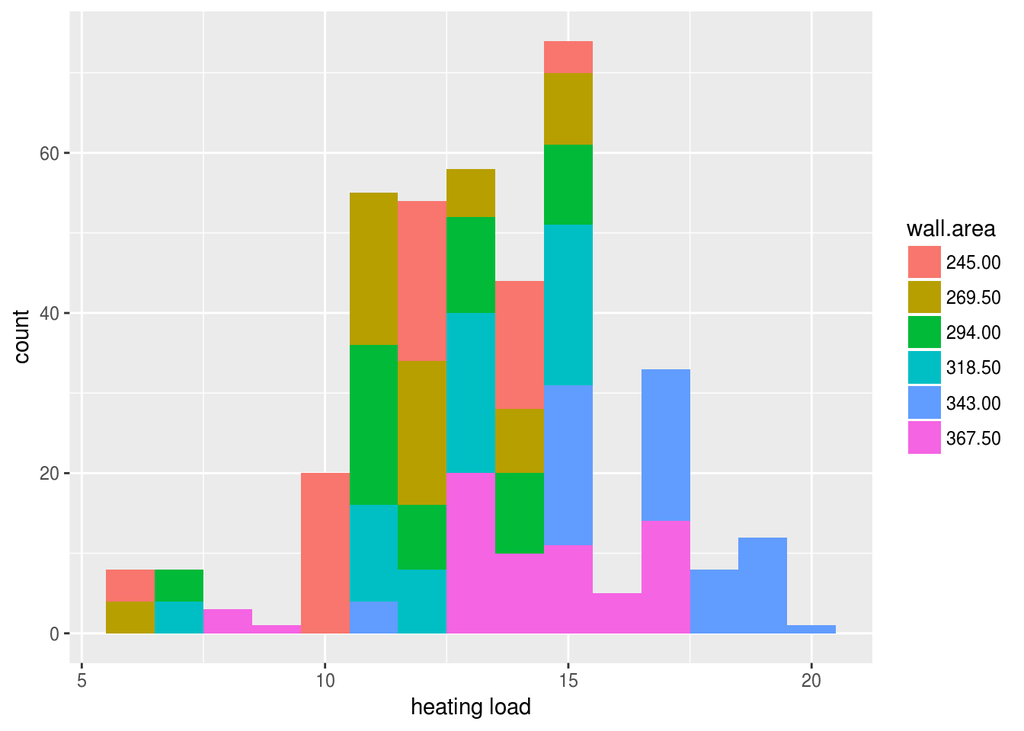

```r
ggplot(eedata3.50, aes(x = heating.load, fill = wall.area)) + geom_histogram(binwidth = 1) + labs(x = "heating load")
```

Again, glazing ratio appears to have the biggest impact, along with the wall area.

```r
testlm <- lm(heating.load ~ glazing.area, data = eedata3.50numeric)
summary(testlm)
```

```
##
## Call:
## lm(formula = heating.load ~ glazing.area, data = eedata3.50numeric)
##
## Residuals:
##     Min      1Q  Median      3Q     Max
## -3.9184 -1.2102 -0.6159  1.0441  4.0366
##
## Coefficients:
##              Estimate Std. Error t value Pr(>|t|)
## (Intercept)    9.9284     0.1901   52.23   <2e-16 ***
## glazing.area  14.5499     0.7052   20.63   <2e-16 ***
## ---
## Signif. codes:  0 '***' 0.001 '**' 0.01 '*' 0.05 '.' 0.1 ' ' 1
##
## Residual standard error: 1.84 on 382 degrees of freedom
## Multiple R-squared:  0.527,  Adjusted R-squared:  0.5258
## F-statistic: 425.7 on 1 and 382 DF,  p-value: < 2.2e-16
```

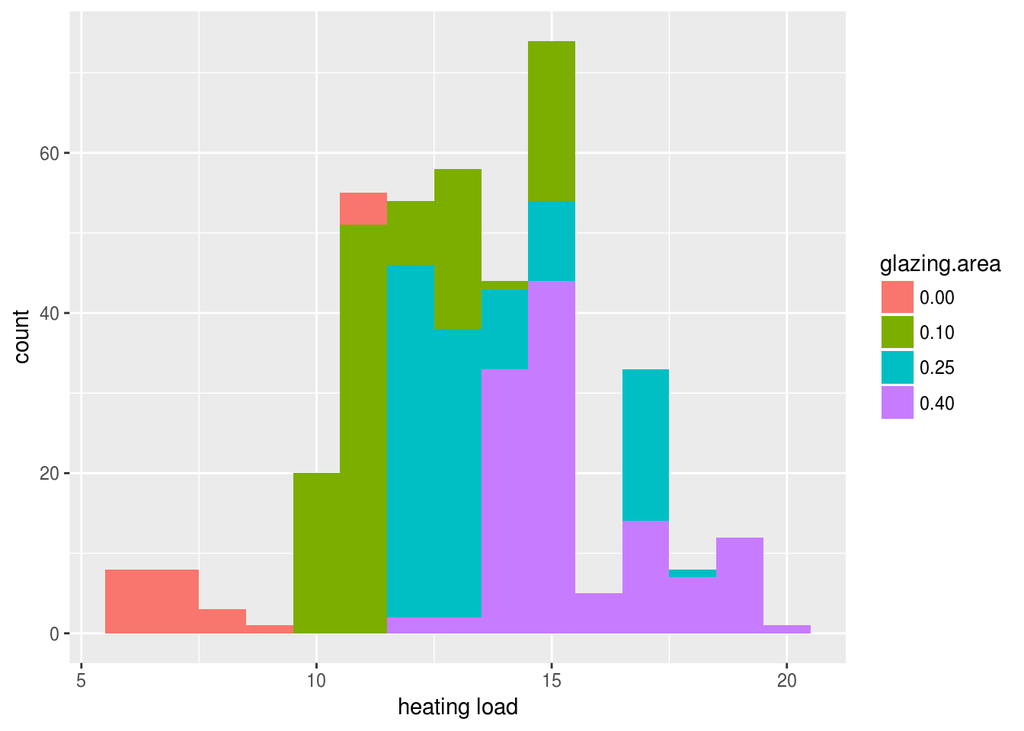

```r
ggplot(eedata3.50, aes(x = heating.load, fill = glazing.area)) + geom_histogram(binwidth = 1) + labs(x = "heating load")
```

Heating facet wraps

```r
testlm <- lm(heating.load ~ glazing.area * wall.area, data = eedatanumeric)
summary(testlm)
```

```
##
## Call:
## lm(formula = heating.load ~ glazing.area * wall.area, data = eedatanumeric)
##
## Residuals:
##     Min      1Q  Median      3Q     Max
## -16.132  -7.872  -1.819   8.585  15.265
##
## Coefficients:
##                         Estimate Std. Error t value Pr(>|t|)
## (Intercept)            -12.68961    4.61763  -2.748  0.00614 **
## glazing.area             6.10124   17.13100   0.356  0.72183
## wall.area                0.09484    0.01436   6.603 7.56e-11 ***
## glazing.area:wall.area   0.04501    0.05329   0.845  0.39855
## ---
## Signif. codes:  0 '***' 0.001 '**' 0.01 '*' 0.05 '.' 0.1 ' ' 1
##
## Residual standard error: 8.572 on 764 degrees of freedom
## Multiple R-squared:  0.2811, Adjusted R-squared:  0.2783
## F-statistic: 99.59 on 3 and 764 DF,  p-value: < 2.2e-16
```

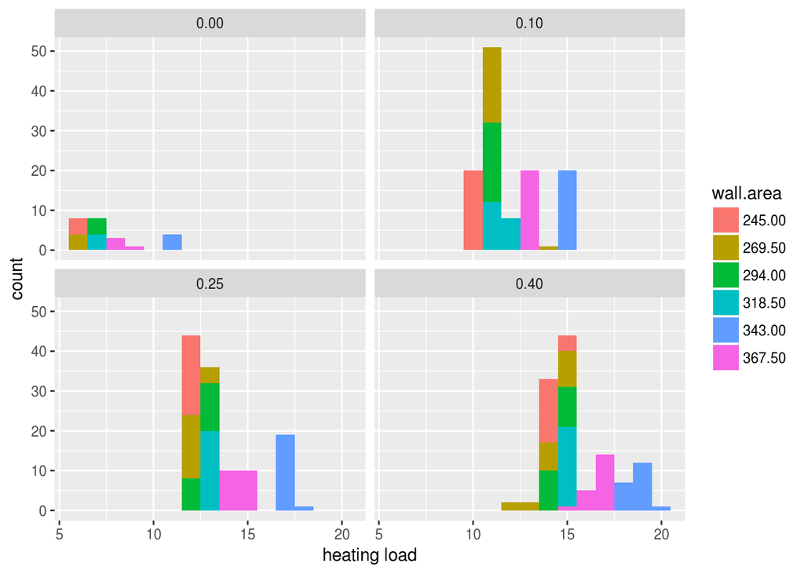

```r
ggplot(eedata3.50, aes(x = heating.load, fill = wall.area)) + geom_histogram(binwidth = 1) + labs(x = "heating load") + facet_wrap(~glazing.area)
```

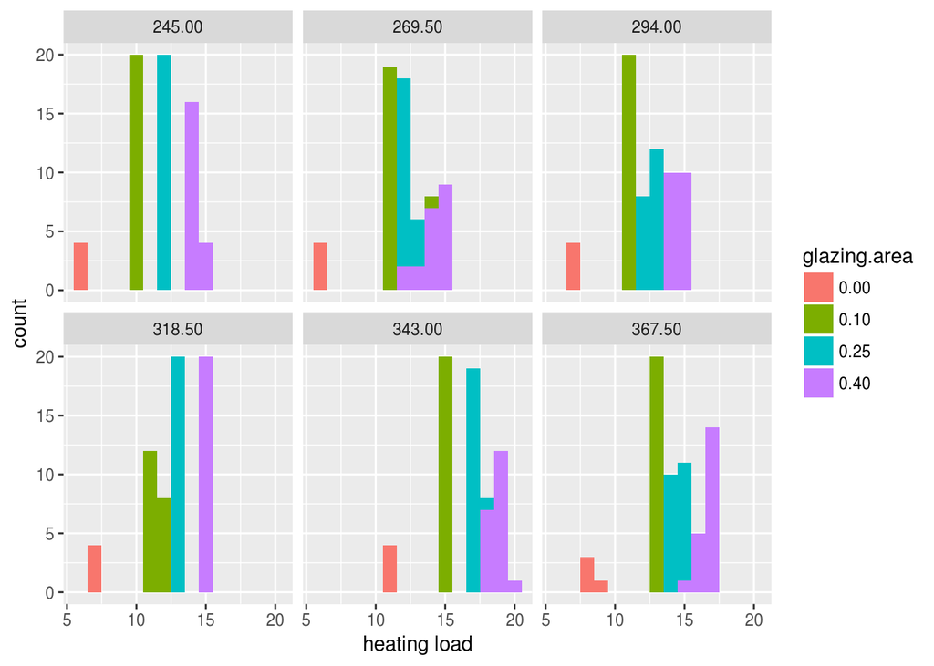

```r
ggplot(eedata3.50, aes(x = heating.load, fill = glazing.area)) + geom_histogram(binwidth = 1) + labs(x = "heating load") + facet_wrap(~wall.area)
```

Now let’s run the 7.0m building

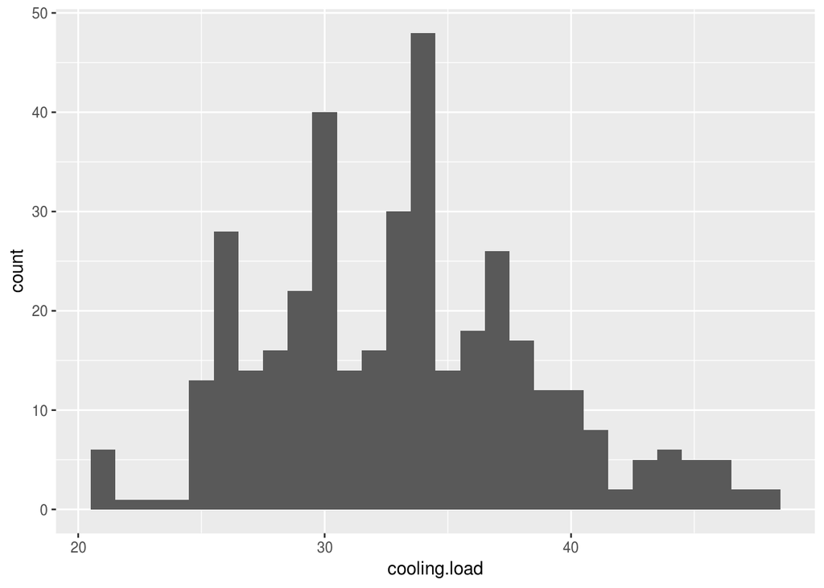

```r
ggplot(eedata7.00, aes(x = cooling.load)) + geom_histogram(binwidth = 1)
```

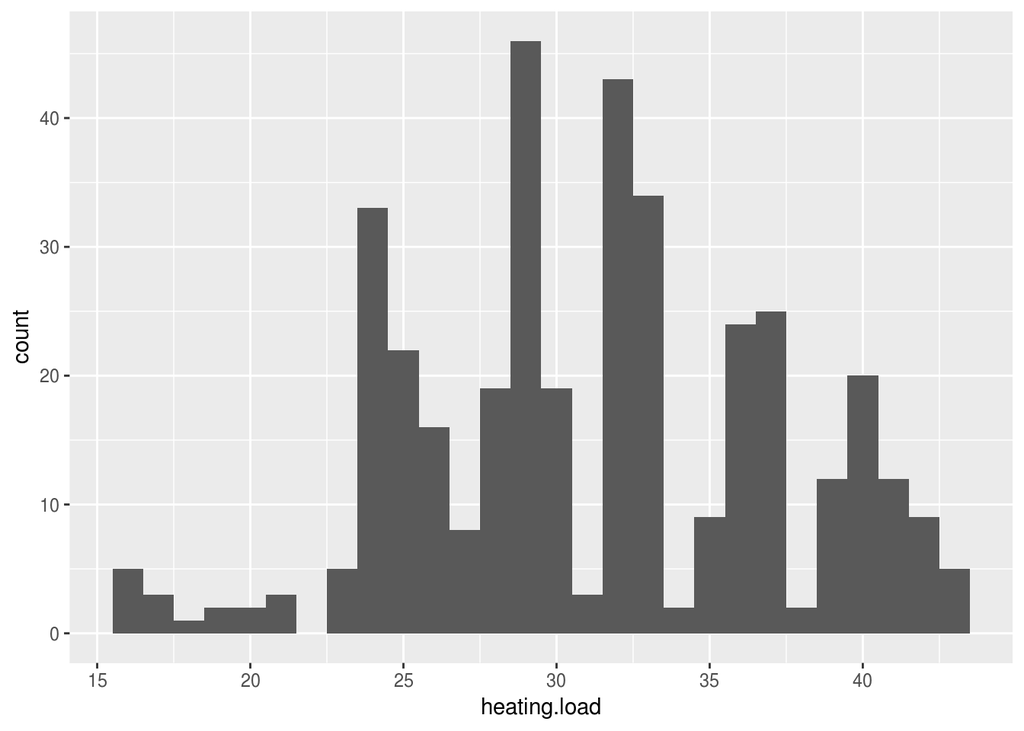

```r
ggplot(eedata7.00, aes(x = heating.load)) + geom_histogram(binwidth = 1)
```

Cooling analysis

```r
testlm <- lm(cooling.load ~ relative.compactness, data = eedata7.00numeric)
summary(testlm)
```

```
##
## Call:
## lm(formula = cooling.load ~ relative.compactness, data = eedata7.00numeric)
##
## Residuals:
##      Min       1Q   Median       3Q      Max
## -12.9948  -3.0064   0.5992   3.4155  12.8798
##
## Coefficients:
##                      Estimate Std. Error t value Pr(>|t|)
## (Intercept)            61.362      2.929  20.950   <2e-16 ***
## relative.compactness  -33.180      3.427  -9.683   <2e-16 ***
## ---
## Signif. codes:  0 '***' 0.001 '**' 0.01 '*' 0.05 '.' 0.1 ' ' 1
##
## Residual standard error: 4.91 on 382 degrees of freedom
## Multiple R-squared:  0.1971, Adjusted R-squared:  0.195
## F-statistic: 93.76 on 1 and 382 DF,  p-value: < 2.2e-16
```

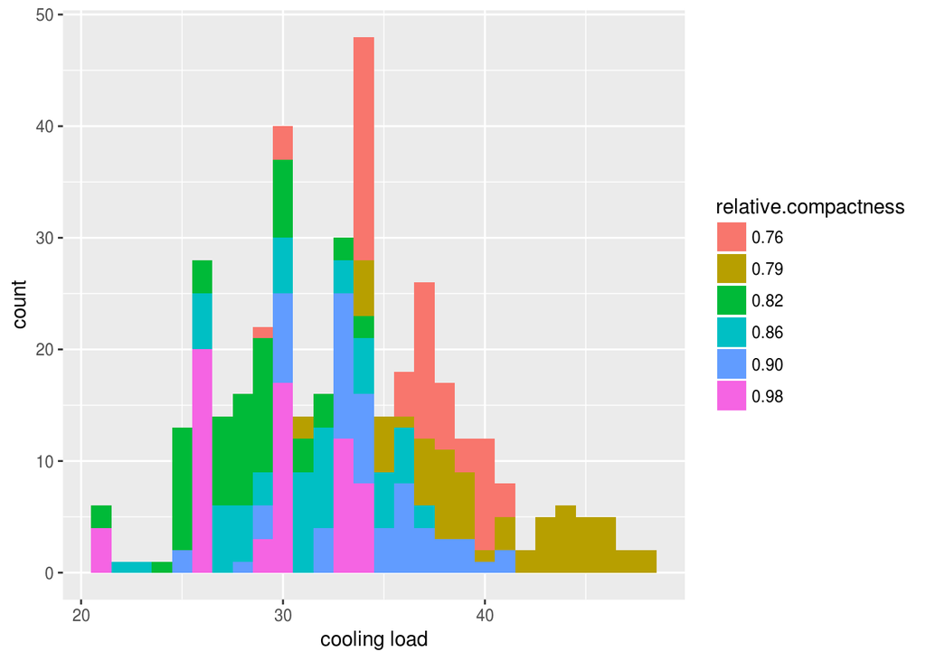

```r
ggplot(eedata7.00, aes(x = cooling.load, fill = relative.compactness)) + geom_histogram(binwidth = 1) + labs(x = "cooling load")
```

```r
testlm <- lm(cooling.load ~ surface.area, data = eedata7.00numeric)
summary(testlm)
```

```
##
## Call:
## lm(formula = cooling.load ~ surface.area, data = eedata7.00numeric)
##
## Residuals:
##      Min       1Q   Median       3Q      Max
## -12.8026  -2.9340   0.3618   3.2738  12.7796
##
## Coefficients:
##              Estimate Std. Error t value Pr(>|t|)
## (Intercept)  1.767915   3.065312   0.577    0.564
## surface.area 0.052563   0.005125  10.256   <2e-16 ***
## ---
## Signif. codes:  0 '***' 0.001 '**' 0.01 '*' 0.05 '.' 0.1 ' ' 1
##
## Residual standard error: 4.852 on 382 degrees of freedom
## Multiple R-squared:  0.2159, Adjusted R-squared:  0.2139
## F-statistic: 105.2 on 1 and 382 DF,  p-value: < 2.2e-16
```

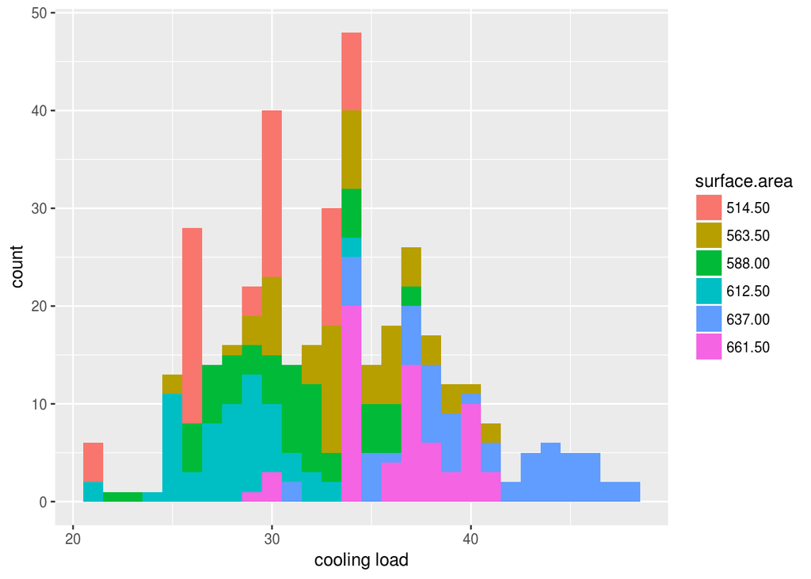

```r
ggplot(eedata7.00, aes(x = cooling.load, fill = surface.area)) + geom_histogram(binwidth = 1) + labs(x = "cooling load")
```

```r
testlm <- lm(cooling.load ~ wall.area, data = eedata7.00numeric)
summary(testlm)
```

```
##
## Call:
## lm(formula = cooling.load ~ wall.area, data = eedata7.00numeric)
##
## Residuals:
##      Min       1Q   Median       3Q      Max
## -11.1890  -3.6865  -0.2242   2.8284  14.1709
##
## Coefficients:
##              Estimate Std. Error t value Pr(>|t|)
## (Intercept) 12.717702   1.964366   6.474 2.93e-10 ***
## wall.area    0.061637   0.005892  10.461  < 2e-16 ***
## ---
## Signif. codes:  0 '***' 0.001 '**' 0.01 '*' 0.05 '.' 0.1 ' ' 1
##
## Residual standard error: 4.831 on 382 degrees of freedom
## Multiple R-squared:  0.2227, Adjusted R-squared:  0.2206
## F-statistic: 109.4 on 1 and 382 DF,  p-value: < 2.2e-16
```

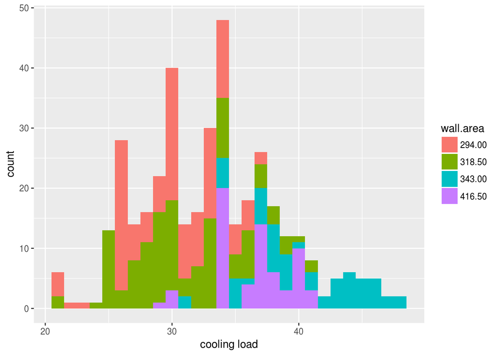

```r
ggplot(eedata7.00, aes(x = cooling.load, fill = wall.area)) + geom_histogram(binwidth = 1) + labs(x = "cooling load")
```

```r
testlm <- lm(cooling.load ~ roof.area, data = eedata7.00numeric)
summary(testlm)
```

```
##
## Call:
## lm(formula = cooling.load ~ roof.area, data = eedata7.00numeric)
##
## Residuals:
##      Min       1Q   Median       3Q      Max
## -12.4224  -3.9624   0.3876   3.6776  14.4476
##
## Coefficients:
##             Estimate Std. Error t value Pr(>|t|)
## (Intercept) 28.66252    2.50184  11.457   <2e-16 ***
## roof.area    0.03347    0.01873   1.786   0.0748 .
## ---
## Signif. codes:  0 '***' 0.001 '**' 0.01 '*' 0.05 '.' 0.1 ' ' 1
##
## Residual standard error: 5.457 on 382 degrees of freedom
## Multiple R-squared:  0.008285,   Adjusted R-squared:  0.005689
## F-statistic: 3.191 on 1 and 382 DF,  p-value: 0.07482
```

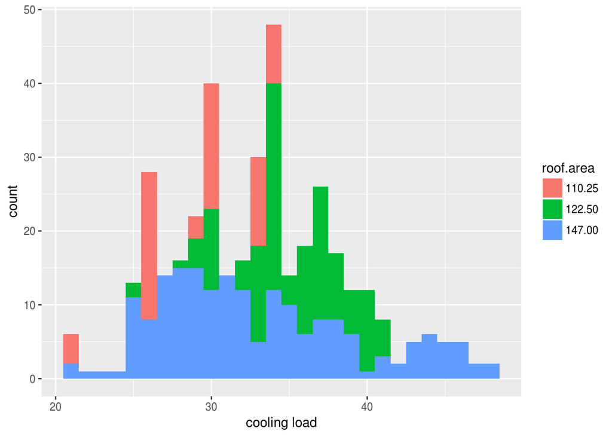

```r
ggplot(eedata7.00, aes(x = cooling.load, fill = roof.area)) + geom_histogram(binwidth = 1) + labs(x = "cooling load")
```

Glazing area doesn’t appear to have the same level of impact on the 7.0m buildings but these are separated to be consistent with the 3.50m findings.

```r
testlm <- lm(cooling.load ~ glazing.area, data = eedata7.00numeric)
summary(testlm)
```

```
##
## Call:
## lm(formula = cooling.load ~ glazing.area, data = eedata7.00numeric)
##
## Residuals:
##     Min      1Q  Median      3Q     Max
## -8.3325 -3.8821 -0.5623  3.3757 12.7884
##
## Coefficients:
##              Estimate Std. Error t value Pr(>|t|)
## (Intercept)   28.6346     0.5014   57.11   <2e-16 ***
## glazing.area  19.0699     1.8600   10.25   <2e-16 ***
## ---
## Signif. codes:  0 '***' 0.001 '**' 0.01 '*' 0.05 '.' 0.1 ' ' 1
##
## Residual standard error: 4.852 on 382 degrees of freedom
## Multiple R-squared:  0.2158, Adjusted R-squared:  0.2137
## F-statistic: 105.1 on 1 and 382 DF,  p-value: < 2.2e-16
```

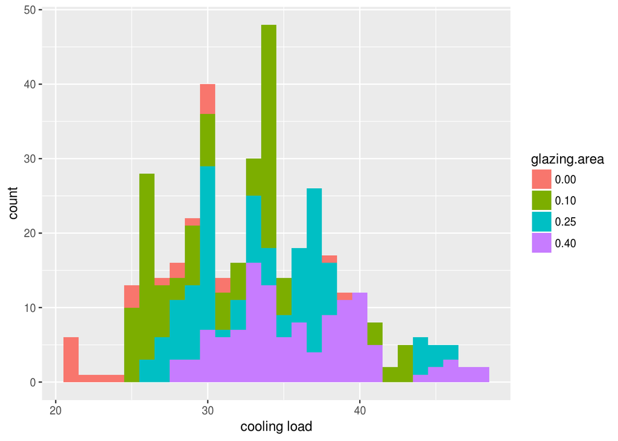

```r
ggplot(eedata7.00, aes(x = cooling.load, fill = glazing.area)) + geom_histogram(binwidth = 1) + labs(x = "cooling load")
```

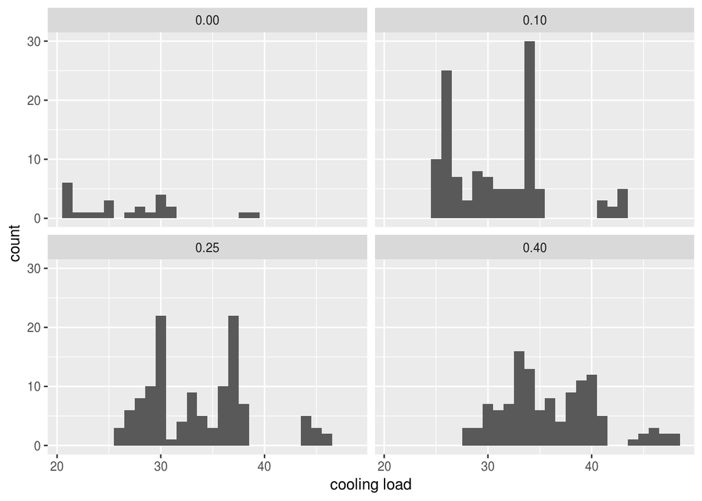

```r
ggplot(eedata7.00, aes(x = cooling.load)) + geom_histogram(binwidth = 1) + labs(x = "cooling load") + facet_wrap(~glazing.area)
```

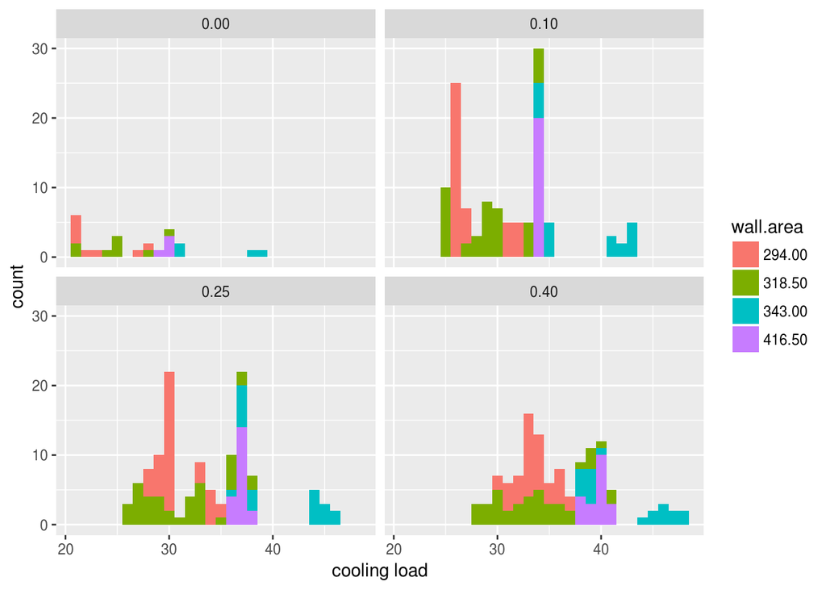

```r
#facet wrap
ggplot(eedata7.00, aes(x = cooling.load, fill = wall.area)) + geom_histogram(binwidth = 1) + labs(x = "cooling load") + facet_wrap(~glazing.area)
```

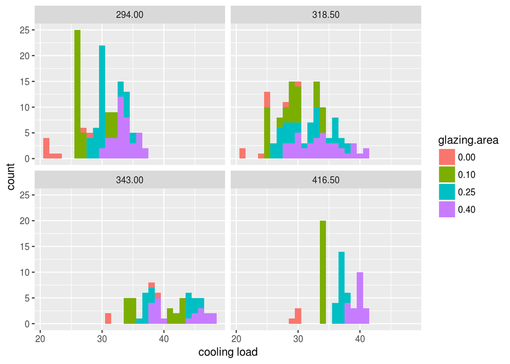

```r
#reverse wrapping
ggplot(eedata7.00, aes(x = cooling.load, fill = glazing.area)) + geom_histogram(binwidth = 1) + labs(x = "cooling load") + facet_wrap(~wall.area)
```

Perform a heating analysis on the 7.0m buildings

```r
testlm <- lm(heating.load ~ relative.compactness, data = eedata7.00numeric)
summary(testlm)
```

```
##
## Call:
## lm(formula = heating.load ~ relative.compactness, data = eedata7.00numeric)
##
## Residuals:
##      Min       1Q   Median       3Q      Max
## -16.4257  -2.9207   0.9914   4.7448   9.6239
##
## Coefficients:
##                      Estimate Std. Error t value Pr(>|t|)
## (Intercept)            61.662      3.196  19.292   <2e-16 ***
## relative.compactness  -35.679      3.739  -9.542   <2e-16 ***
## ---
## Signif. codes:  0 '***' 0.001 '**' 0.01 '*' 0.05 '.' 0.1 ' ' 1
##
## Residual standard error: 5.358 on 382 degrees of freedom
## Multiple R-squared:  0.1925, Adjusted R-squared:  0.1904
## F-statistic: 91.05 on 1 and 382 DF,  p-value: < 2.2e-16
```

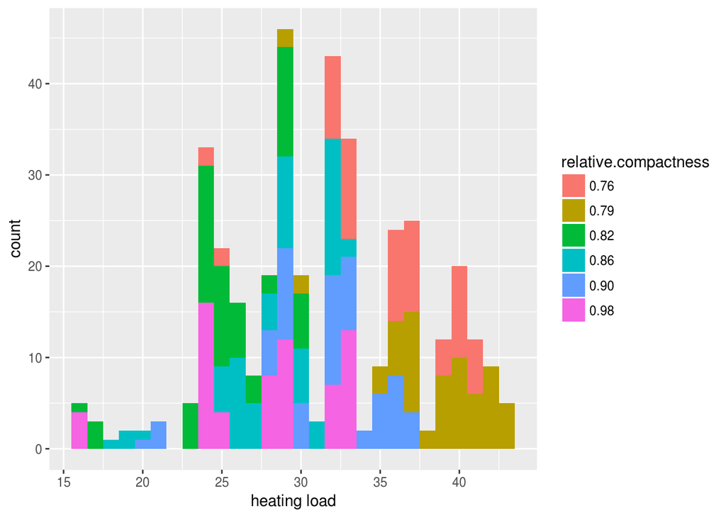

```r
ggplot(eedata7.00, aes(x = heating.load, fill = relative.compactness)) + geom_histogram(binwidth = 1) + labs(x = "heating load")
```

```r
testlm <- lm(heating.load ~ surface.area, data = eedata7.00numeric)
summary(testlm)
```

```
##
## Call:
## lm(formula = heating.load ~ surface.area, data = eedata7.00numeric)
##
## Residuals:
##      Min       1Q   Median       3Q      Max
## -16.2286  -2.8192   0.9919   4.4033   9.4924
##
## Coefficients:
##               Estimate Std. Error t value Pr(>|t|)
## (Intercept)  -2.767643   3.336822  -0.829    0.407
## surface.area  0.057104   0.005579  10.236   <2e-16 ***
## ---
## Signif. codes:  0 '***' 0.001 '**' 0.01 '*' 0.05 '.' 0.1 ' ' 1
##
## Residual standard error: 5.282 on 382 degrees of freedom
## Multiple R-squared:  0.2152, Adjusted R-squared:  0.2132
## F-statistic: 104.8 on 1 and 382 DF,  p-value: < 2.2e-16
```

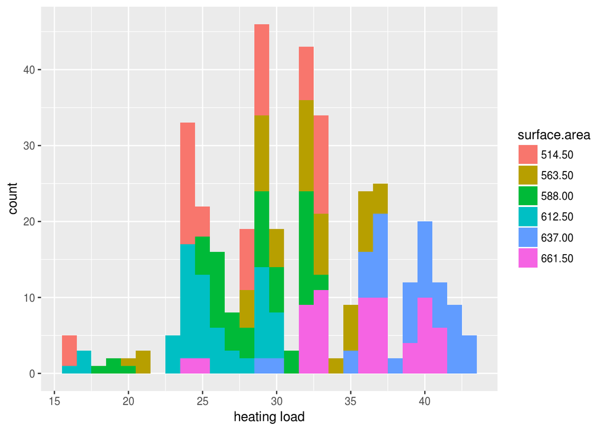

```r
ggplot(eedata7.00, aes(x = heating.load, fill = surface.area)) + geom_histogram(binwidth = 1) + labs(x = "heating load")
```

```r
testlm <- lm(heating.load ~ wall.area, data = eedata7.00numeric)
summary(testlm)
```

```
##
## Call:
## lm(formula = heating.load ~ wall.area, data = eedata7.00numeric)
##
## Residuals:
##      Min       1Q   Median       3Q      Max
## -14.4034  -3.9683  -0.2133   3.6467  10.9316
##
## Coefficients:
##             Estimate Std. Error t value Pr(>|t|)
## (Intercept) 7.177783   2.081549   3.448 0.000627 ***
## wall.area   0.072859   0.006244  11.669  < 2e-16 ***
## ---
## Signif. codes:  0 '***' 0.001 '**' 0.01 '*' 0.05 '.' 0.1 ' ' 1
##
## Residual standard error: 5.119 on 382 degrees of freedom
## Multiple R-squared:  0.2628, Adjusted R-squared:  0.2609
## F-statistic: 136.2 on 1 and 382 DF,  p-value: < 2.2e-16
```

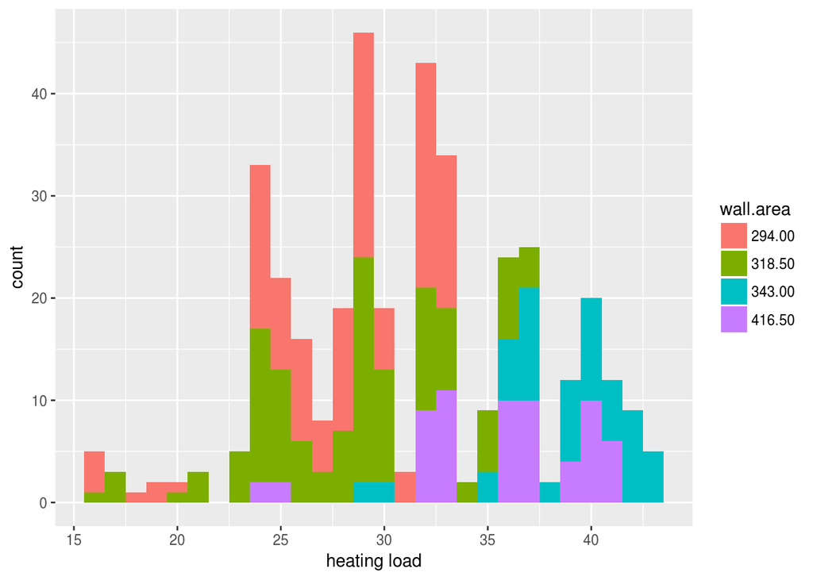

```r
ggplot(eedata7.00, aes(x = heating.load, fill = wall.area)) + geom_histogram(binwidth = 1) + labs(x = "heating load")
```

```r
testlm <- lm(heating.load ~ roof.area, data = eedata7.00numeric)
summary(testlm)
```

```
##
## Call:
## lm(formula = heating.load ~ roof.area, data = eedata7.00numeric)
##
## Residuals:
##      Min       1Q   Median       3Q      Max
## -15.4816  -4.4541   0.4076   4.8243  11.6384
##
## Coefficients:
##             Estimate Std. Error t value Pr(>|t|)
## (Intercept) 29.55130    2.73217  10.816   <2e-16 ***
## roof.area    0.01300    0.02046   0.635    0.526
## ---
## Signif. codes:  0 '***' 0.001 '**' 0.01 '*' 0.05 '.' 0.1 ' ' 1
##
## Residual standard error: 5.959 on 382 degrees of freedom
## Multiple R-squared:  0.001055,   Adjusted R-squared:  -0.00156
## F-statistic: 0.4034 on 1 and 382 DF,  p-value: 0.5257
```

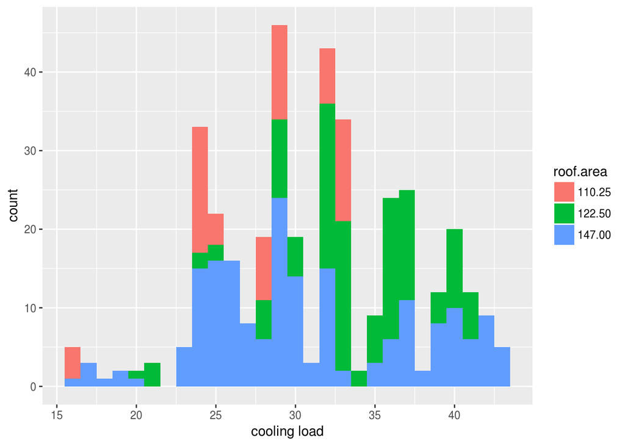

```r
ggplot(eedata7.00, aes(x = heating.load, fill = roof.area)) + geom_histogram(binwidth = 1) + labs(x = "cooling load")
```

Glazing area results

```r
testlm <- lm(heating.load ~ glazing.area, data = eedata7.00numeric)
summary(testlm)
```

```
##
## Call:
## lm(formula = heating.load ~ glazing.area, data = eedata7.00numeric)
##
## Residuals:
##    Min     1Q Median     3Q    Max
## -9.556 -3.507 -1.263  4.664  9.522
##
## Coefficients:
##              Estimate Std. Error t value Pr(>|t|)
## (Intercept)   25.1058     0.4977   50.45   <2e-16 ***
## glazing.area  26.3258     1.8463   14.26   <2e-16 ***
## ---
## Signif. codes:  0 '***' 0.001 '**' 0.01 '*' 0.05 '.' 0.1 ' ' 1
##
## Residual standard error: 4.817 on 382 degrees of freedom
## Multiple R-squared:  0.3474, Adjusted R-squared:  0.3456
## F-statistic: 203.3 on 1 and 382 DF,  p-value: < 2.2e-16
```

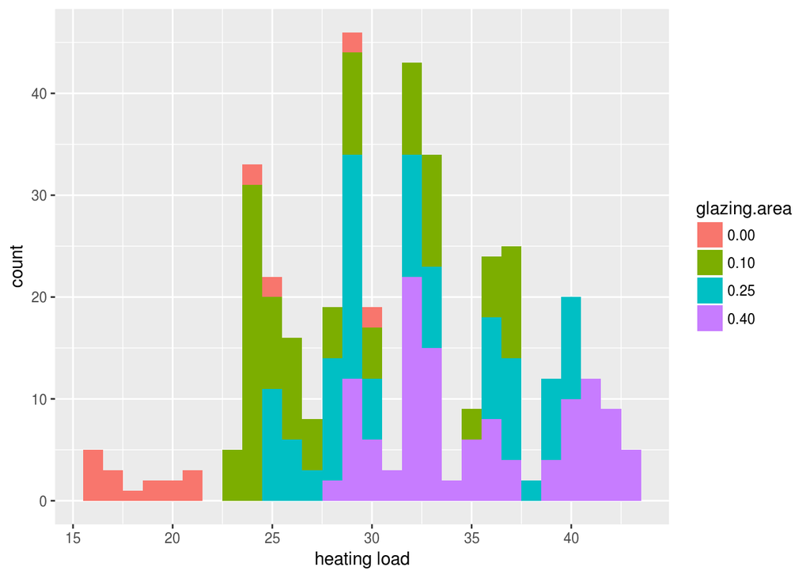

```r
ggplot(eedata7.00, aes(x = heating.load, fill = glazing.area)) + geom_histogram(binwidth = 1) + labs(x = "heating load")
```

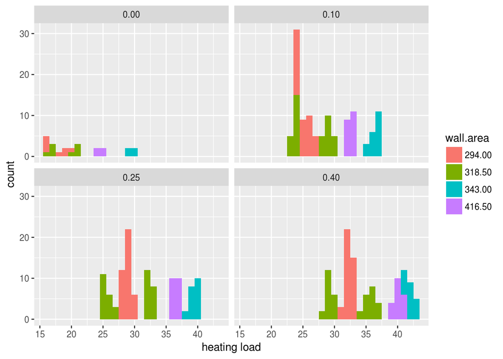

```r
#facet wrap
ggplot(eedata7.00, aes(x = heating.load, fill = wall.area)) + geom_histogram(binwidth = 1) + labs(x = "heating load") + facet_wrap(~glazing.area)
```

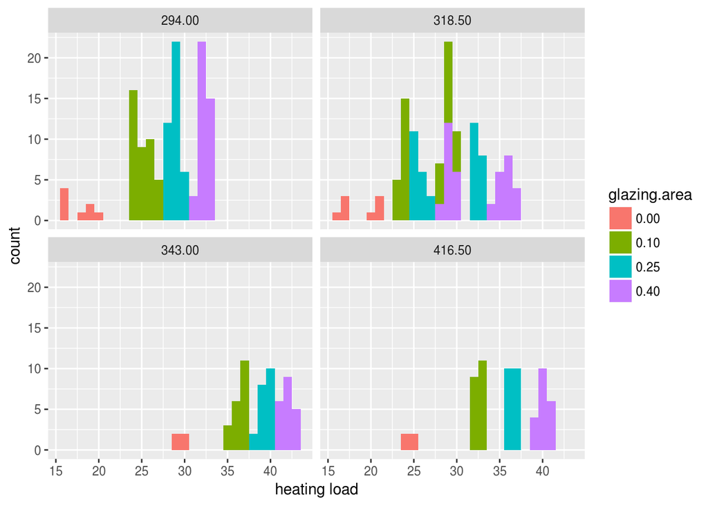

```r
#reverse wrapping
ggplot(eedata7.00, aes(x = heating.load, fill = glazing.area)) + geom_histogram(binwidth = 1) + labs(x = "heating load") + facet_wrap(~wall.area)
```

Question - 3 Graphics: Please make sure to display at least one scatter plot, box plot and histogram. Don’t be limited to this. Please explore the many other options in R packages such as ggplot2.

## Summary

Let’s put together some summary graphs.

Cooling - scatter plot separating 3.50 vs. 7 meter buildings by wall area and glazing ratio.

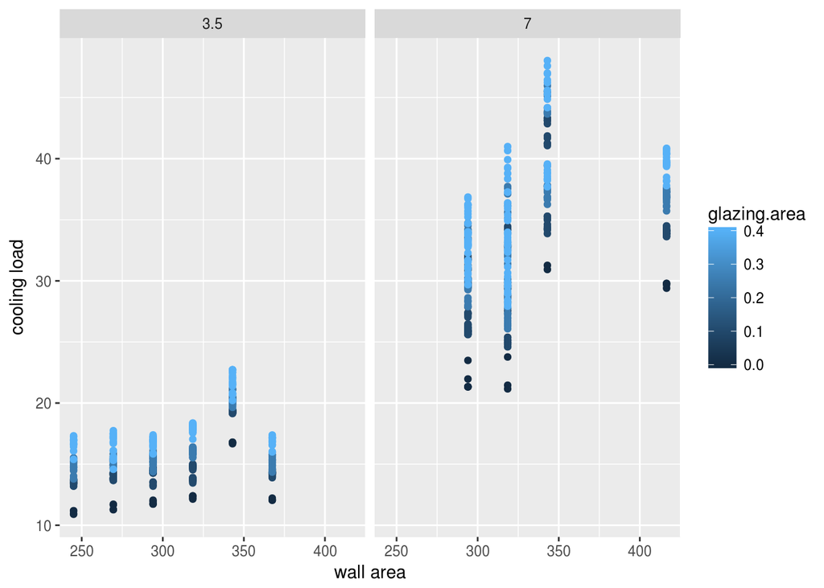

```r
ggplot(eedatanumeric, aes(y = cooling.load, x = wall.area)) + geom_point(aes(color = glazing.area)) + facet_wrap(~overall.height) + labs(x = "wall area", y = "cooling load")
```

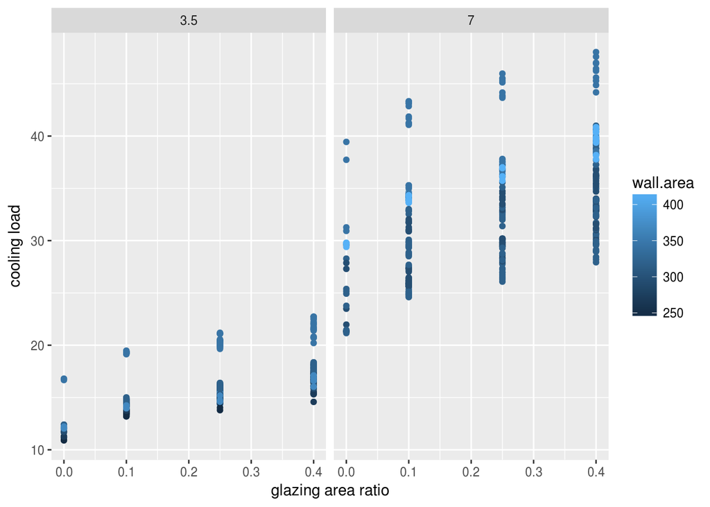

```r
ggplot(eedatanumeric, aes(y = cooling.load, x = glazing.area)) + geom_point(aes(color = wall.area)) + facet_wrap(~overall.height) + labs(x = "glazing area ratio", y = "cooling load")
```

Heating - scatter plot separating 3.50 vs. 7 meter buildings by wall area and glazing ratio.

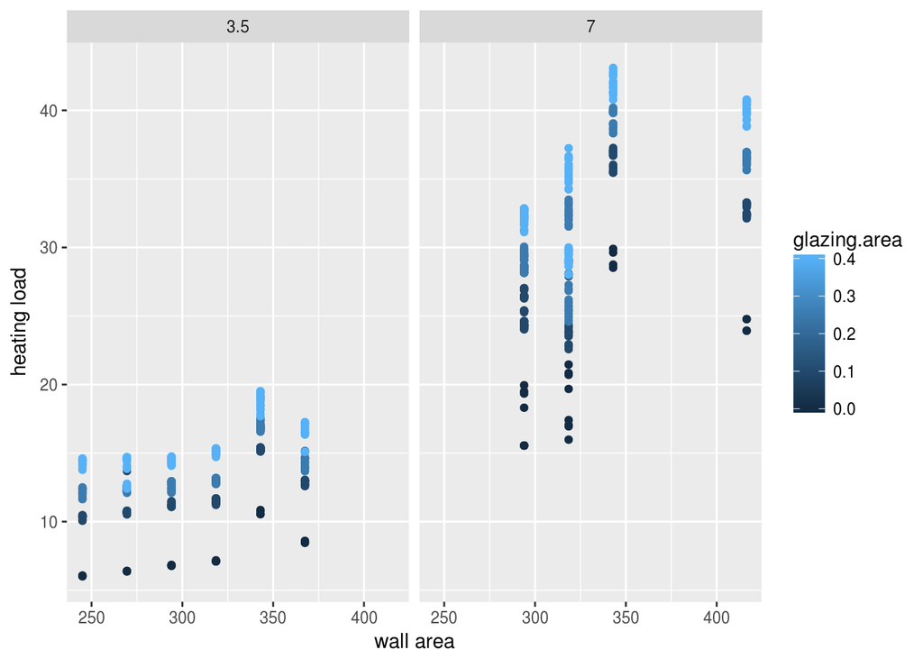

```r
ggplot(eedatanumeric, aes(y = heating.load, x = wall.area)) + geom_point(aes(color = glazing.area)) + facet_wrap(~overall.height) + labs(x = "wall area", y = "heating load")
```

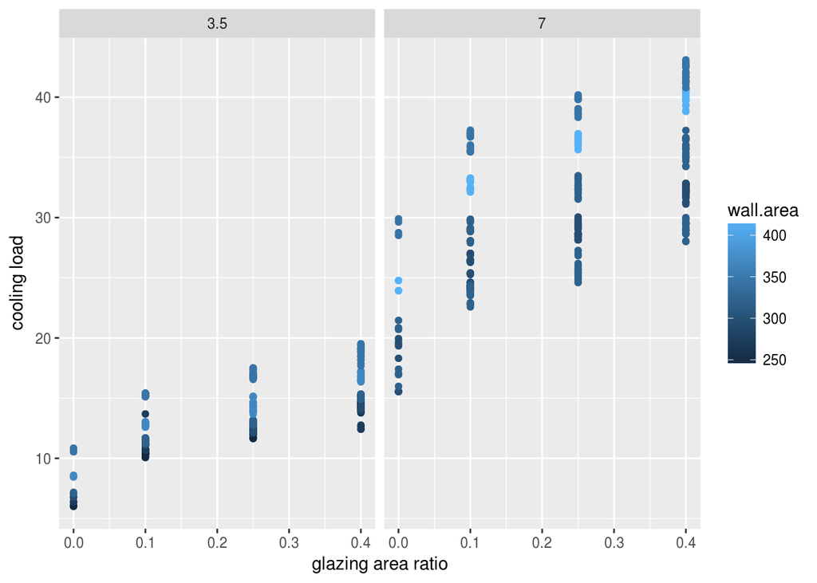

```r
ggplot(eedatanumeric, aes(y = heating.load, x = glazing.area)) + geom_point(aes(color = wall.area)) + facet_wrap(~overall.height) + labs(x = "glazing area ratio", y = "cooling load")
```

As we can see be the summary graphs, it appears that as the glazing area ratio and wall area increase, the heating and cooling loads will generally increase as well. This is also shown by graphing the actual glazing area (glazing area ratio * wall area) against the heating and cooling loads. However, due to low quality of fit in many of the tests run in this analysis, it appears there may be more factors influencing the response variables.

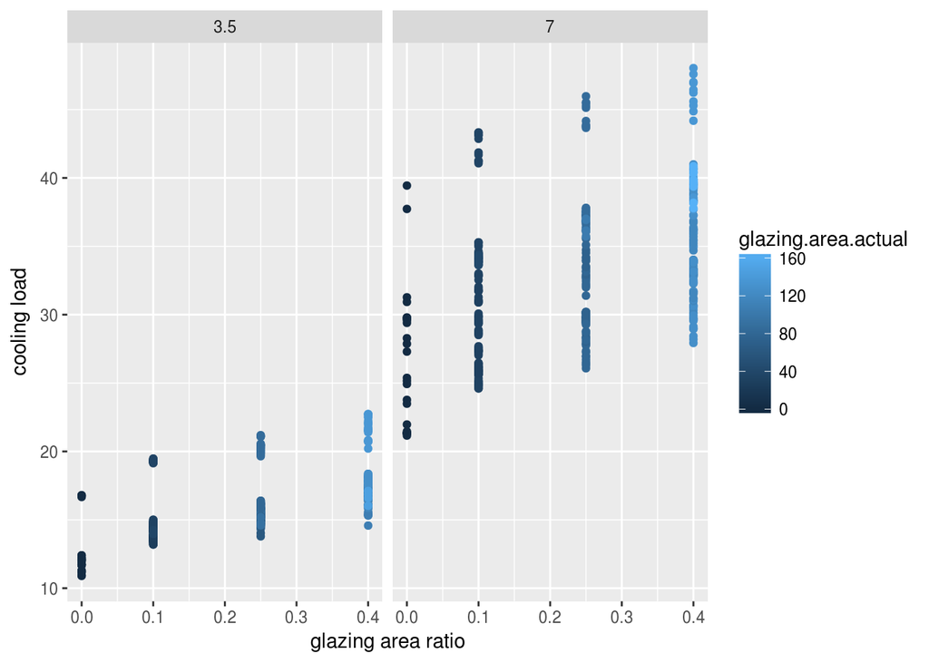

```r
ggplot(eedatanumeric, aes(y = cooling.load, x = glazing.area)) + geom_point(aes(color = glazing.area.actual)) + facet_wrap(~overall.height) + labs(x = "glazing area ratio", y = "cooling load")
```

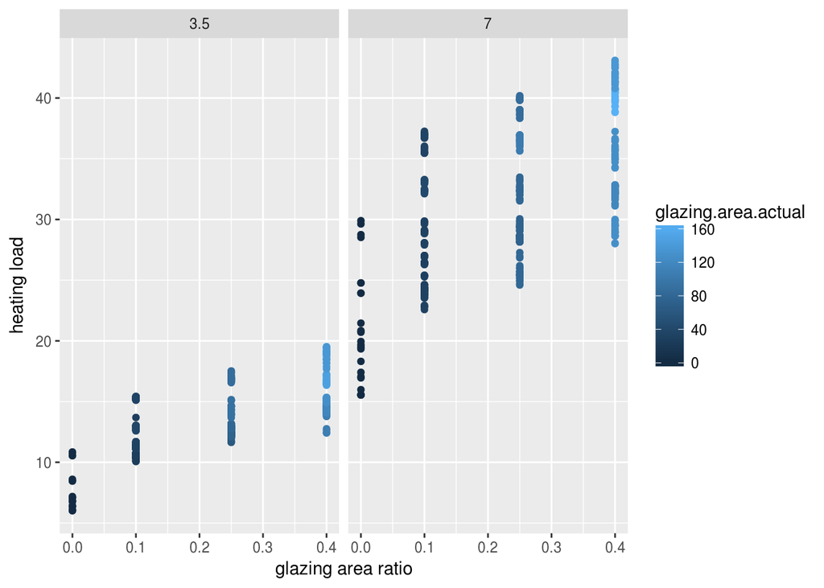

```r
ggplot(eedatanumeric, aes(y = heating.load, x = glazing.area)) + geom_point(aes(color = glazing.area.actual)) + facet_wrap(~overall.height) + labs(x = "glazing area ratio", y = "heating load")
```